# STAT456 Group Project

Dylan Nguyen, Blake Pohevitz, Akanksha Sharma

2024-11-23

```r
library(dplyr)
```

```r
library(ggplot2)
library(leaps)
library(tidyverse)
library(GGally)
library(glmnet)
library(caret)
```

Processing dataset

```r
setwd("C:/Users/Dylan/Desktop/GMU/fall 2024/stat456/group project 3")
data <- read.csv("CarPrice_Assignment.csv")
```

```r
datanew <- data %>%
  mutate(fueltype = recode_factor(fueltype, '0' = "gas", '1' = "diesel")) %>%
  mutate(aspiration = recode_factor(aspiration,'0'='std','1'='turbo')) %>%
  mutate(doornumber = recode_factor(doornumber,'0'='two','1'='four')) %>%
  mutate(carbody = recode_factor(carbody,'0'='hatchback','1'='wagon','2'='sedan','3'='convertible','4'='hardtop')) %>%
  mutate(drivewheel = recode_factor(drivewheel,'0'='fwd','1'='rwd','2'='4wd')) %>%
  mutate(enginelocation = recode_factor(enginelocation,'0'='front','1'='back')) %>%
  mutate(enginetype = recode_factor(enginetype,'0'='dohc','1'='dohcv','2'='l','3'='ohc','4'='ohcf','5'='ohcv','6'='rotor')) %>%
  mutate(cylindernumber = recode_factor(cylindernumber,'0'='two','1'='three','2'='four','3'='five','4'='six','8'='eight','9'='twelve')) %>%
  mutate(fuelsystem = recode_factor(fuelsystem,'0'='1bbl','1'='2bbl','2'='idi','3'='mfi','4'='mpfi','8'='spdi','9'='spfi'))
colnames(datanew)
```

```
##  [1] "car_ID"           "symboling"        "CarName"          "fueltype"
##  [5] "aspiration"       "doornumber"       "carbody"          "drivewheel"
##  [9] "enginelocation"   "wheelbase"        "carlength"        "carwidth"
## [13] "carheight"        "curbweight"       "enginetype"       "cylindernumber"
## [17] "enginesize"       "fuelsystem"       "boreratio"        "stroke"
## [21] "compressionratio" "horsepower"       "peakrpm"          "citympg"
## [25] "highwaympg"       "price"
```

#Splitting the Data into Train and Test Dataset

```r
data.train <- datanew[1:165,]
data.test <- datanew[166:205,]
```

#Exploring the relationships between Prices and other variables.

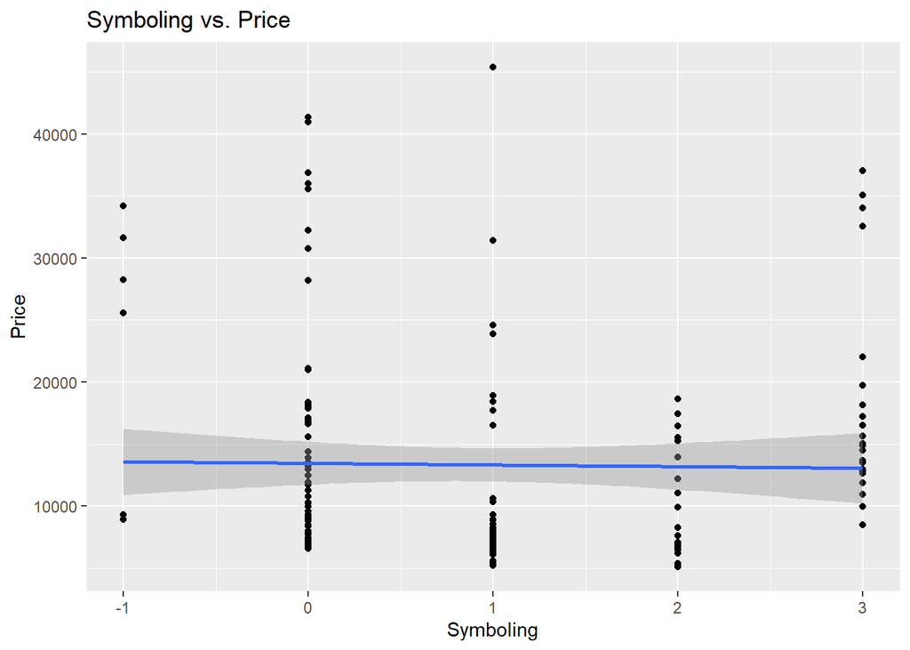

```r
numeric_columns <- sapply(data.train, is.numeric)
numeric_data <- data.train[, numeric_columns]

ggplot(data.train, aes(x = symboling, y = price)) + geom_point() + geom_smooth(method = "lm") + labs(title = "Symboling vs. Price", x = "Symboling", y = "Price")
```

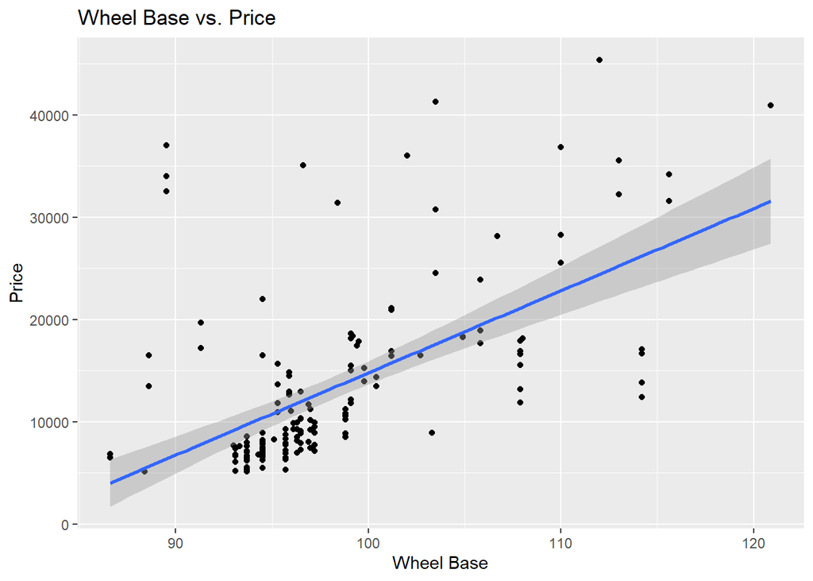

```r
ggplot(data.train, aes(x = wheelbase, y = price)) + geom_point() + geom_smooth(method = "lm") + labs(title = "Wheel Base vs. Price", x = "Wheel Base", y = "Price")
```

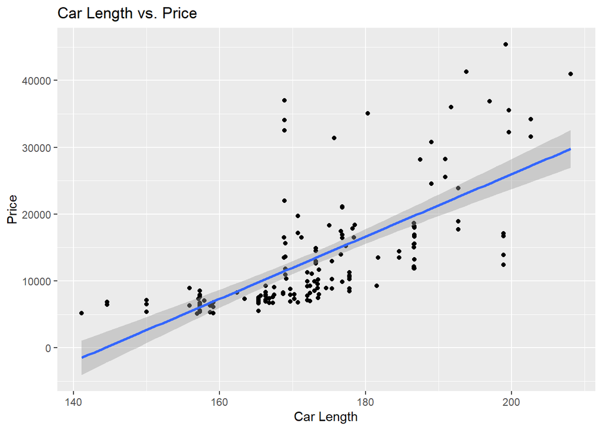

```r
ggplot(data.train, aes(x = carlength, y = price)) + geom_point() + geom_smooth(method = "lm") + labs(title = "Car Length vs. Price", x = "Car Length", y = "Price")
```

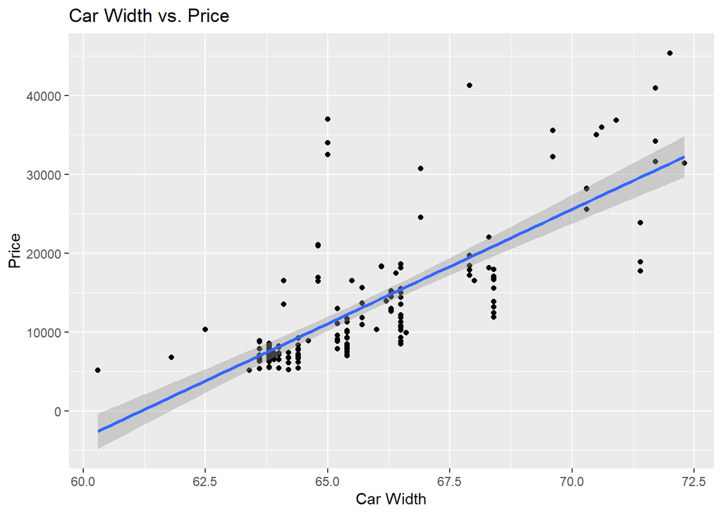

```r
ggplot(data.train, aes(x = carwidth, y = price)) + geom_point() + geom_smooth(method = "lm") + labs(title = "Car Width vs. Price", x = "Car Width", y = "Price")
```

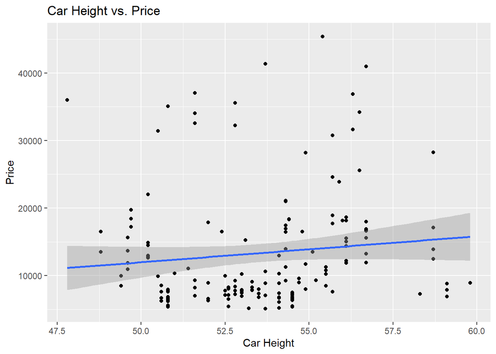

```r
ggplot(data.train, aes(x = carheight, y = price)) + geom_point() + geom_smooth(method = "lm") + labs(title = "Car Height vs. Price", x = "Car Height", y = "Price")
```

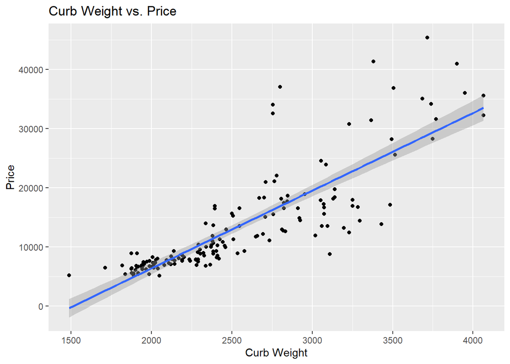

```r
ggplot(data.train, aes(x = curbweight, y = price)) + geom_point() + geom_smooth(method = "lm") + labs(title = "Curb Weight vs. Price", x = "Curb Weight", y = "Price")
```

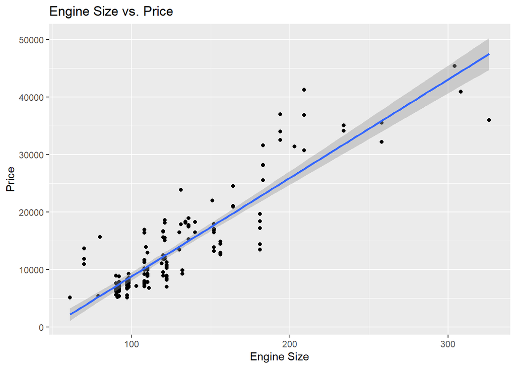

```r
ggplot(data.train, aes(x = enginesize, y = price)) + geom_point() + geom_smooth(method = "lm") + labs(title = "Engine Size vs. Price", x = "Engine Size", y = "Price")
```

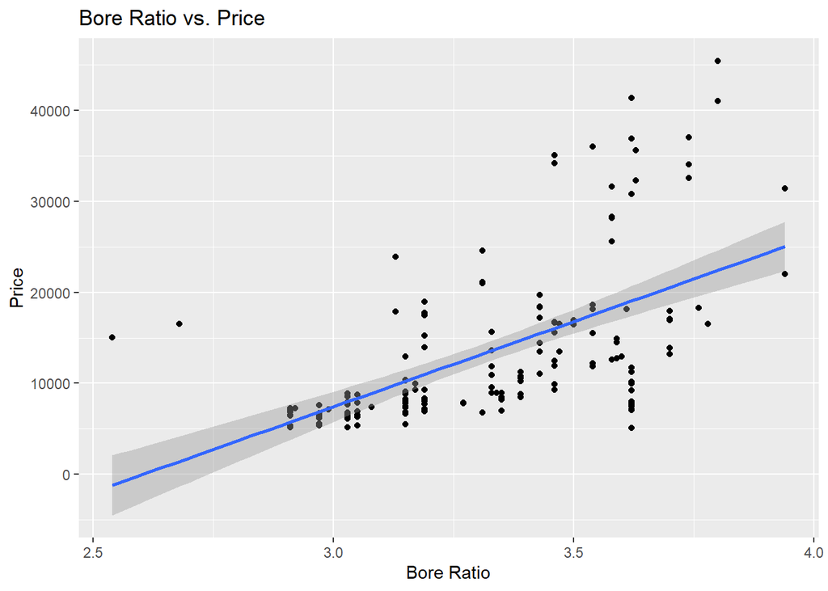

```r
ggplot(data.train, aes(x = boreratio, y = price)) + geom_point() + geom_smooth(method = "lm") + labs(title = "Bore Ratio vs. Price", x = "Bore Ratio", y = "Price")
```

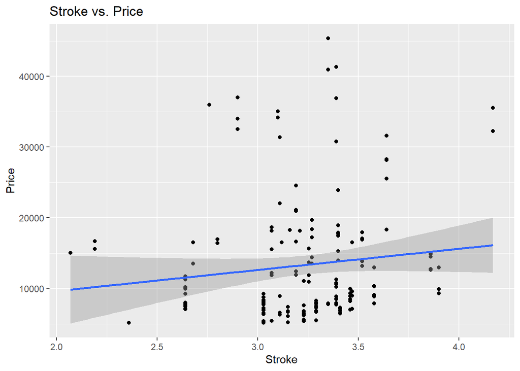

```r
ggplot(data.train, aes(x = stroke, y = price)) + geom_point() + geom_smooth(method = "lm") + labs(title = "Stroke vs. Price", x = "Stroke", y = "Price")
```

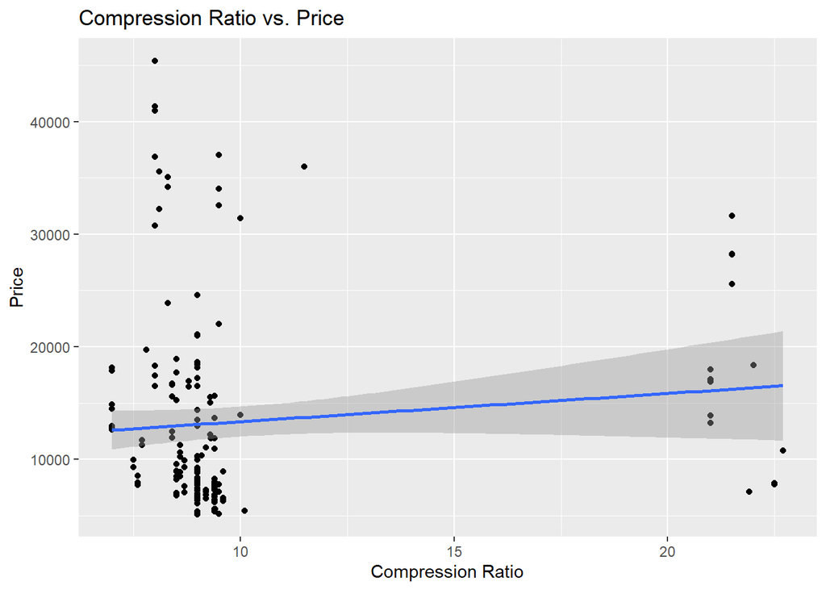

```r
ggplot(data.train, aes(x = compressionratio, y = price)) + geom_point() + geom_smooth(method = "lm") + labs(title = "Compression Ratio vs. Price", x = "Compression Ratio", y = "Price")
```

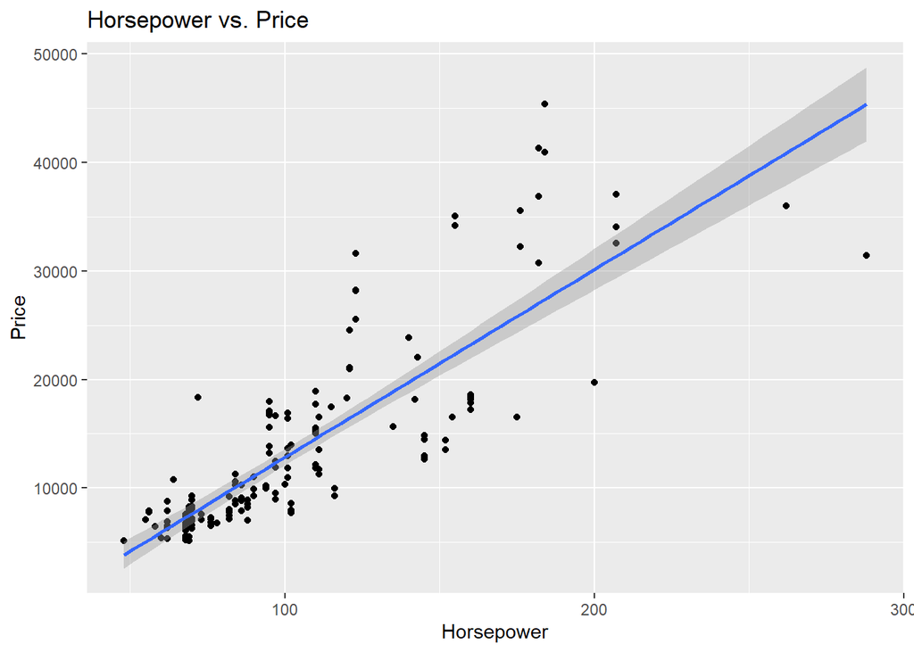

```r
ggplot(data.train, aes(x = horsepower, y = price)) + geom_point() + geom_smooth(method = "lm") + labs(title = "Horsepower vs. Price", x = "Horsepower", y = "Price")
```

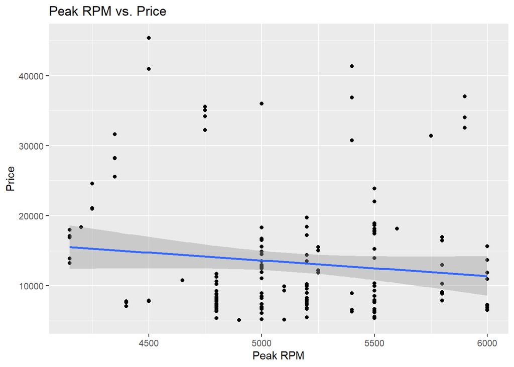

```r
ggplot(data.train, aes(x = peakrpm, y = price)) + geom_point() + geom_smooth(method = "lm") + labs(title = "Peak RPM vs. Price", x = "Peak RPM", y = "Price")
```

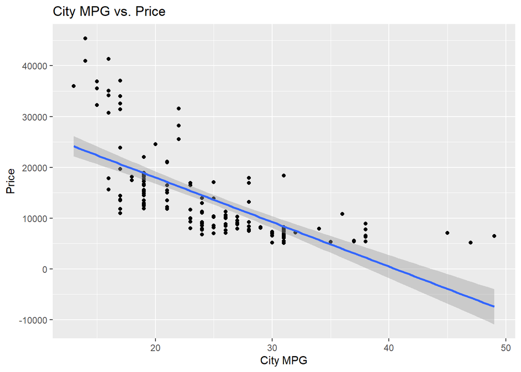

```r
ggplot(data.train, aes(x = citympg, y = price)) + geom_point() + geom_smooth(method = "lm") + labs(title = "City MPG vs. Price", x = "City MPG", y = "Price")
```

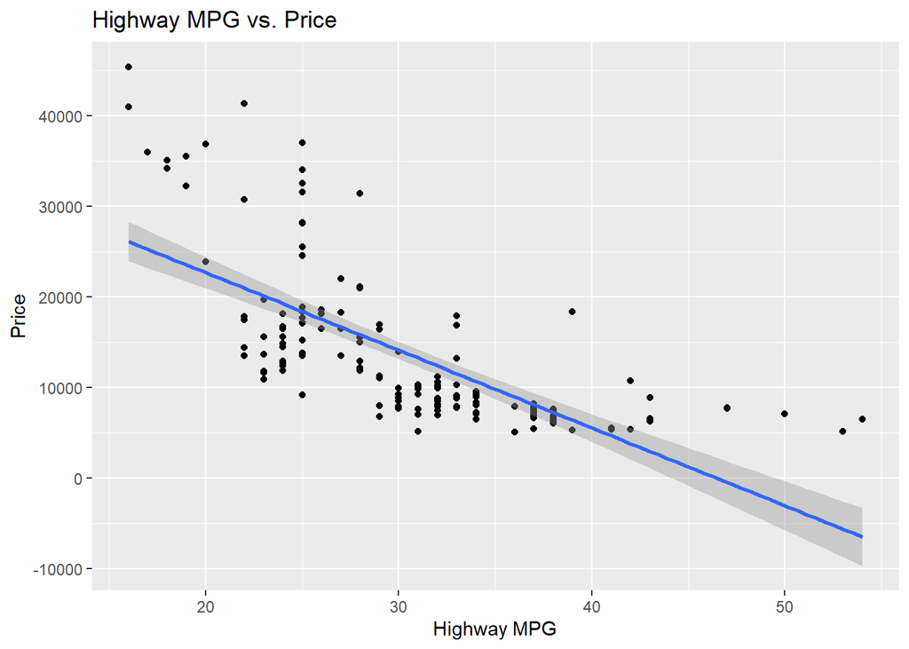

```r
ggplot(data.train, aes(x = highwaympg, y = price)) + geom_point() + geom_smooth(method = "lm") + labs(title = "Highway MPG vs. Price", x = "Highway MPG", y = "Price")
```

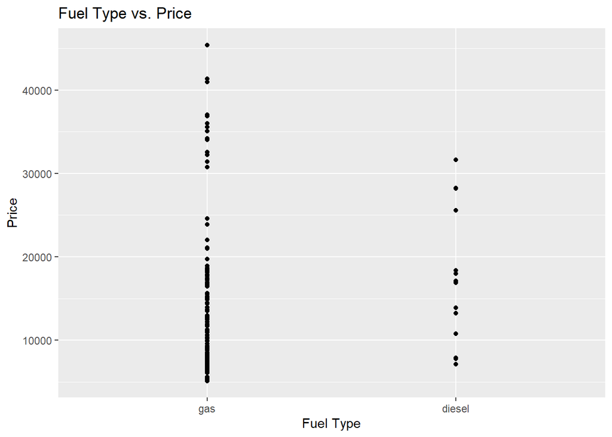

```r
ggplot(data.train, aes(x = fueltype, y = price)) + geom_point() + geom_smooth(method = "lm") + labs(title = "Fuel Type vs. Price", x = "Fuel Type", y = "Price")
```

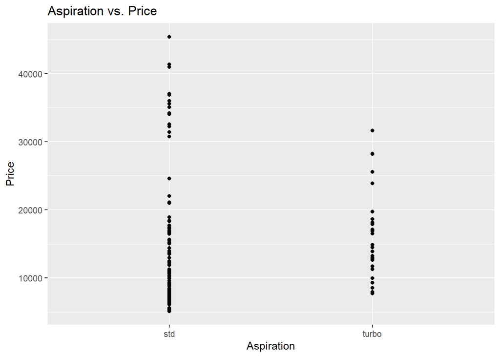

```r
ggplot(data.train, aes(x = aspiration, y = price)) + geom_point() + geom_smooth(method = "lm") + labs(title = "Aspiration vs. Price", x = "Aspiration", y = "Price")
```

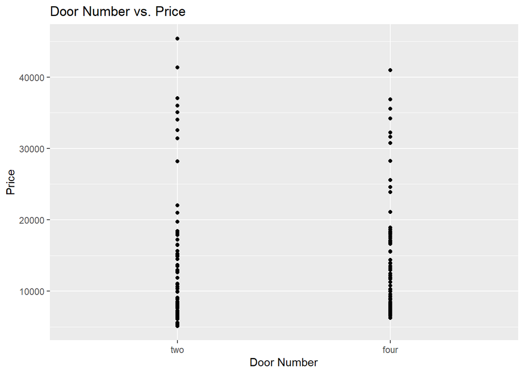

```r
ggplot(data.train, aes(x = doornumber, y = price)) + geom_point() + geom_smooth(method = "lm") + labs(title = "Door Number vs. Price", x = "Door Number", y = "Price")
```

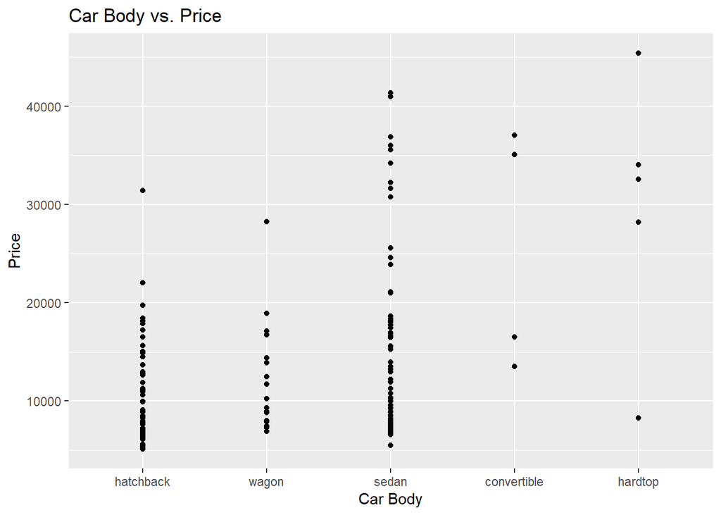

```r
ggplot(data.train, aes(x = carbody, y = price)) + geom_point() + geom_smooth(method = "lm") + labs(title = "Car Body vs. Price", x = "Car Body", y = "Price")
```

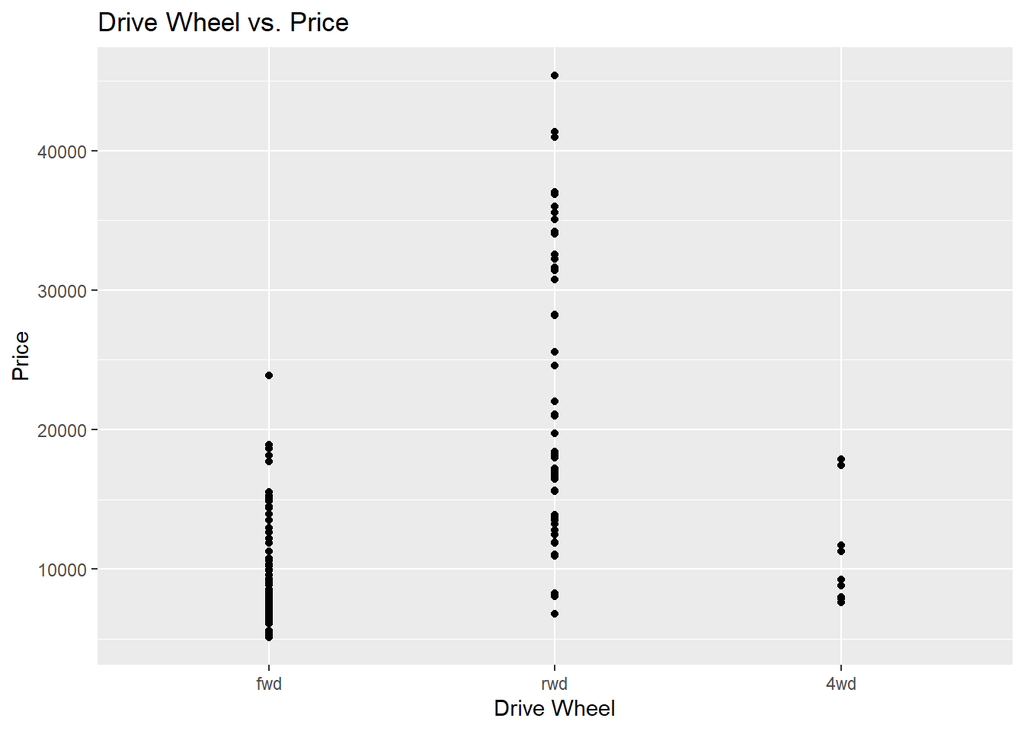

```r
ggplot(data.train, aes(x = drivewheel, y = price)) + geom_point() + geom_smooth(method = "lm") + labs(title = "Drive Wheel vs. Price", x = "Drive Wheel", y = "Price")
```

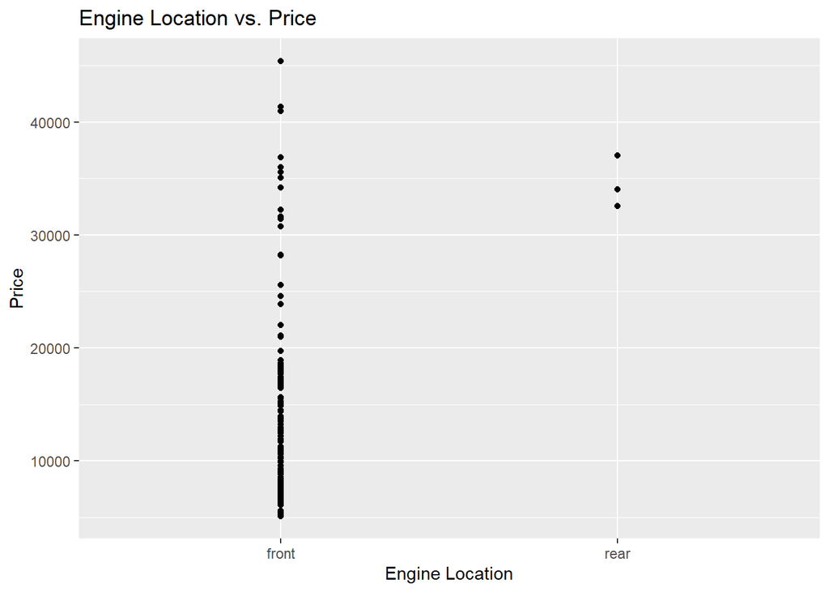

```r
ggplot(data.train, aes(x = enginelocation, y = price)) + geom_point() + geom_smooth(method = "lm") + labs(title = "Engine Location vs. Price", x = "Engine Location", y = "Price")
```

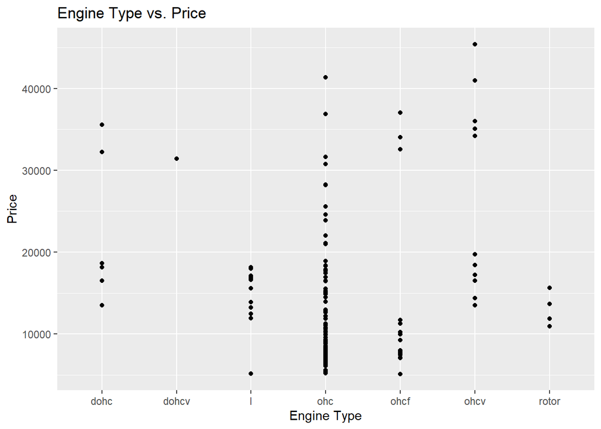

```r
ggplot(data.train, aes(x = enginetype, y = price)) + geom_point() + geom_smooth(method = "lm") + labs(title = "Engine Type vs. Price", x = "Engine Type", y = "Price")
```

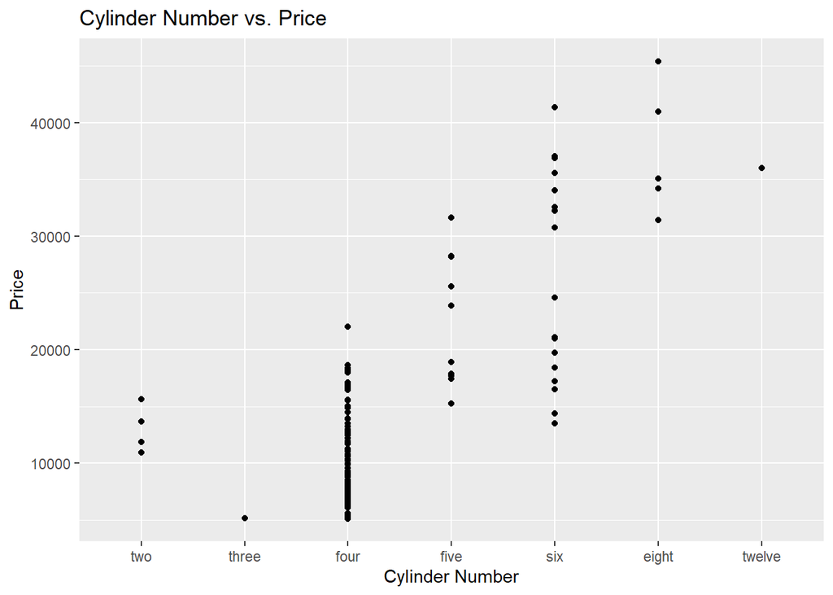

```r
ggplot(data.train, aes(x = cylindernumber, y = price)) + geom_point() + geom_smooth(method = "lm") + labs(title = "Cylinder Number vs. Price", x = "Cylinder Number", y = "Price")
```

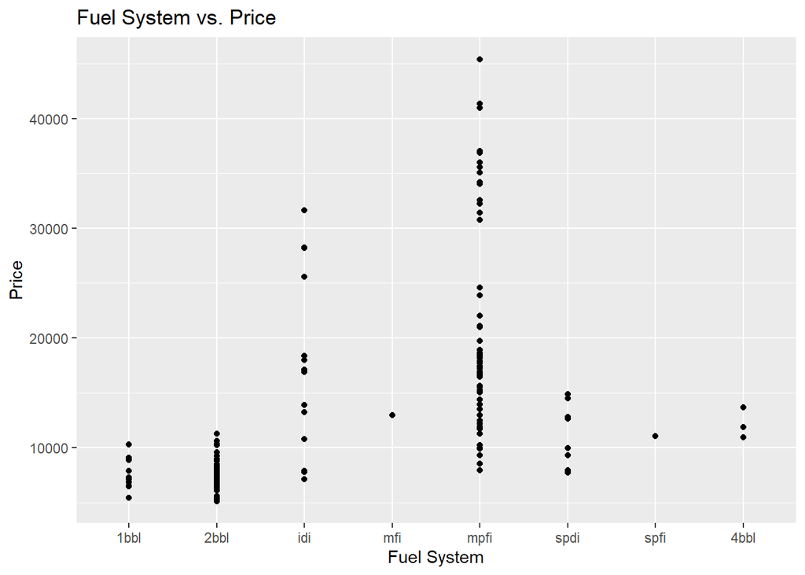

```r
ggplot(data.train, aes(x = fuelsystem, y = price)) + geom_point() + geom_smooth(method = "lm") + labs(title = "Fuel System vs. Price", x = "Fuel System", y = "Price")
```

# Apply Transformations to citympg and highwaympg as they are exponential decay functions.

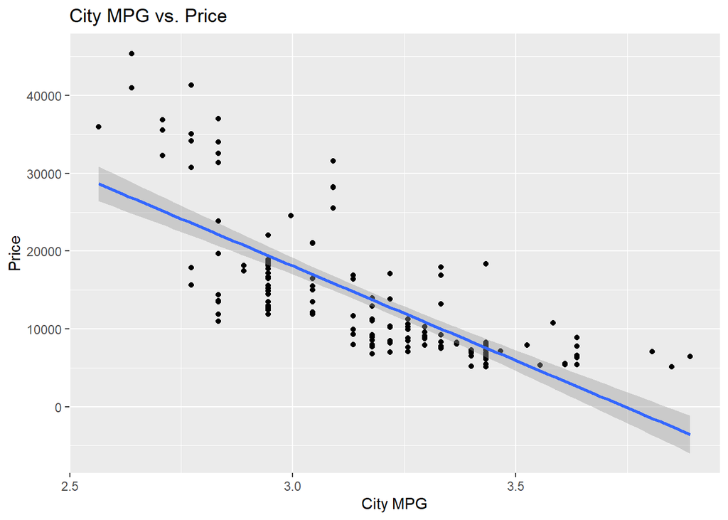

```r
data.train$citympg <- log(data.train$citympg)
data.train$highwaympg <- log(data.train$highwaympg)

data.test$citympg <- log(data.test$citympg)
data.test$highwaympg <- log(data.test$highwaympg)

ggplot(data.train, aes(x = citympg, y = price)) + geom_point() + geom_smooth(method = "lm") + labs(title = "City MPG vs. Price", x = "City MPG", y = "Price")
```

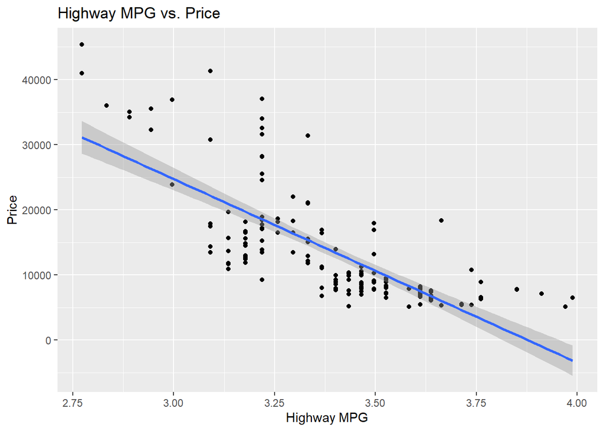

```r
ggplot(data.train, aes(x = highwaympg, y = price)) + geom_point() + geom_smooth(method = "lm") + labs(title = "Highway MPG vs. Price", x = "Highway MPG", y = "Price")
```

# selected variables that were chosen after looking at scatterplots of predictors and fitting model.

```r
selected.vars.train <- data.train[, c("price", "wheelbase", "carlength", "carwidth", "curbweight",
                            "enginesize", "boreratio", "horsepower", "citympg",
                            "highwaympg", "cylindernumber", "carbody", "enginelocation"
                            )]
selected.vars.train
```

|  | price | wheelbase | carlength | carwidth | curbweight | enginesize | boreratio | horsepower | citympg | highwaympg | cylindernumber | carbody | enginelocation |
| --- | --- | --- | --- | --- | --- | --- | --- | --- | --- | --- | --- | --- | --- |
| 1 | 13495.00 | 88.6 | 168.8 | 64.1 | 2548 | 130 | 3.47 | 111 | 3.044522 | 3.295837 | four | convertible | front |
| 2 | 16500.00 | 88.6 | 168.8 | 64.1 | 2548 | 130 | 3.47 | 111 | 3.044522 | 3.295837 | four | convertible | front |
| 3 | 16500.00 | 94.5 | 171.2 | 65.5 | 2823 | 152 | 2.68 | 154 | 2.944439 | 3.258097 | six | hatchback | front |
| 4 | 13950.00 | 99.8 | 176.6 | 66.2 | 2337 | 109 | 3.19 | 102 | 3.178054 | 3.401197 | four | sedan | front |
| 5 | 17450.00 | 99.4 | 176.6 | 66.4 | 2824 | 136 | 3.19 | 115 | 2.890372 | 3.091042 | five | sedan | front |
| 6 | 15250.00 | 99.8 | 177.3 | 66.3 | 2507 | 136 | 3.19 | 110 | 2.944439 | 3.218876 | five | sedan | front |
| 7 | 17710.00 | 105.8 | 192.7 | 71.4 | 2844 | 136 | 3.19 | 110 | 2.944439 | 3.218876 | five | sedan | front |
| 8 | 18920.00 | 105.8 | 192.7 | 71.4 | 2954 | 136 | 3.19 | 110 | 2.944439 | 3.218876 | five | wagon | front |
| 9 | 23875.00 | 105.8 | 192.7 | 71.4 | 3086 | 131 | 3.13 | 140 | 2.833213 | 2.995732 | five | sedan | front |
| 10 | 17859.17 | 99.5 | 178.2 | 67.9 | 3053 | 131 | 3.13 | 160 | 2.772589 | 3.091042 | five | hatchback | front |

[output cut: 155 more lines]

```r
selected.vars.test <- data.test[, c("price", "wheelbase", "carlength", "carwidth", "curbweight",
                            "enginesize", "boreratio", "horsepower", "citympg",
                            "highwaympg", "cylindernumber", "carbody", "enginelocation"
                            )]
```

Variables that seem to have a relationship with price by looking at the predictor vs price scatterplots: wheelbase, carlength, carwidth, curbweight, enginesize, boreratio, horsepower, mpg, highwaympg

*variables that don’t have enough data/dont show relationship are removed

These variables serve a baseline to our given model, and do NOT represent final selection of variables for the model.

##STEPWISE SELECTION

```r
best_stepwise_subset <- regsubsets(price ~ ., data=selected.vars.train,nvmax=18)
summary_best_stepwise_subset <- summary(best_stepwise_subset)
summary_best_stepwise_subset
```

```
## Subset selection object
## Call: regsubsets.formula(price ~ ., data = selected.vars.train, nvmax = 18)
## 20 Variables  (and intercept)
##                      Forced in Forced out
## wheelbase                FALSE      FALSE
## carlength                FALSE      FALSE
## carwidth                 FALSE      FALSE
## curbweight               FALSE      FALSE
## enginesize               FALSE      FALSE
## boreratio                FALSE      FALSE
## horsepower               FALSE      FALSE
## citympg                  FALSE      FALSE
## highwaympg               FALSE      FALSE
## cylindernumberthree      FALSE      FALSE
## cylindernumberfour       FALSE      FALSE
```

[output cut: 106 more lines]

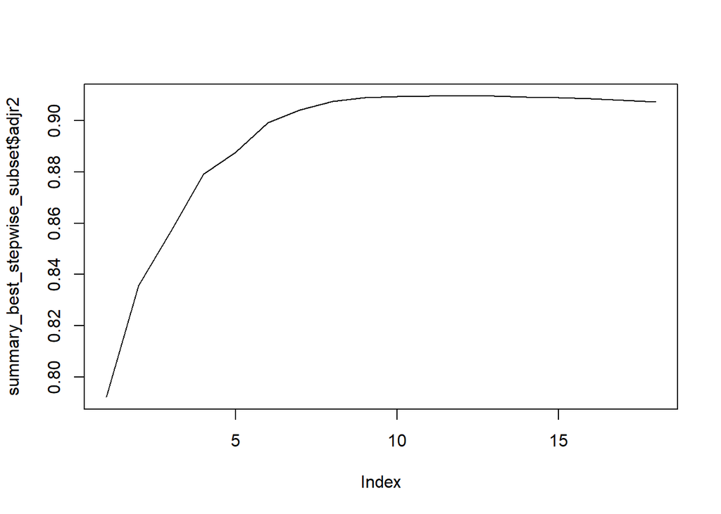

```r
plot(summary_best_stepwise_subset$adjr2, type="l")
```

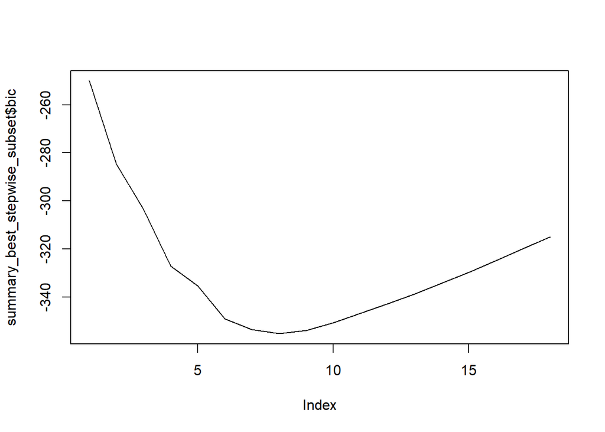

```r
plot(summary_best_stepwise_subset$bic, type="l")
```

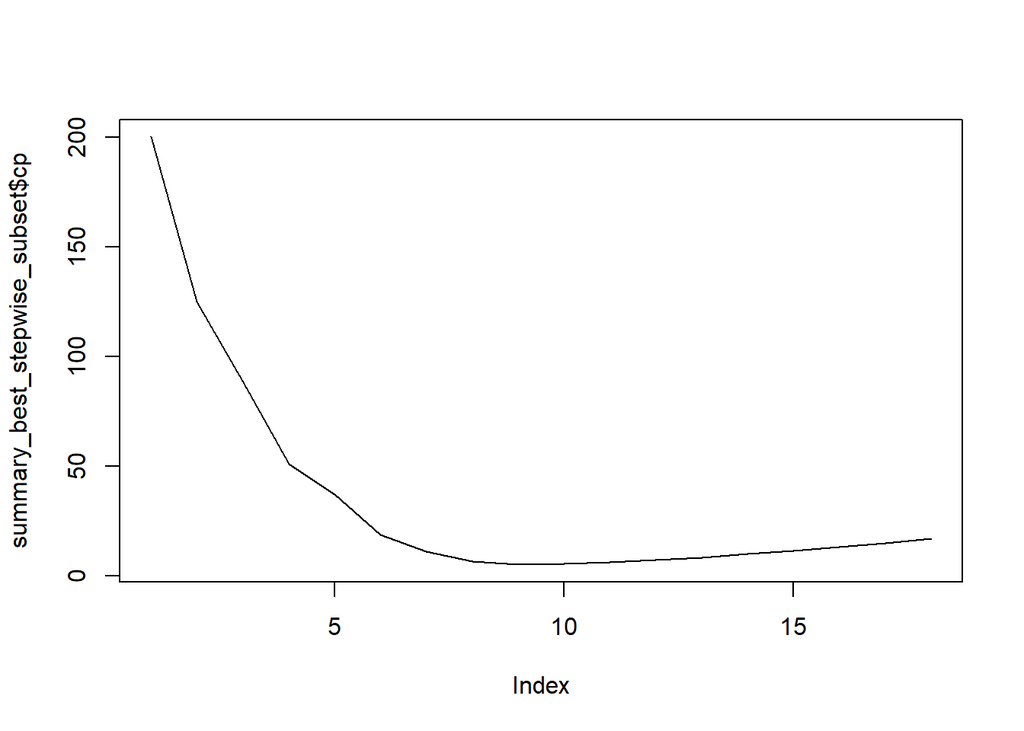

```r
plot(summary_best_stepwise_subset$cp, type="l")
```

##forward selection

```r
best_forward_subset <- regsubsets(price ~ ., data=selected.vars.train,nvmax=18,, method = "forward")
summary_best_forward_subset <- summary(best_forward_subset)
summary_best_forward_subset
```

```
## Subset selection object
## Call: regsubsets.formula(price ~ ., data = selected.vars.train, nvmax = 18,
##     , method = "forward")
## 20 Variables  (and intercept)
##                      Forced in Forced out
## wheelbase                FALSE      FALSE
## carlength                FALSE      FALSE
## carwidth                 FALSE      FALSE
## curbweight               FALSE      FALSE
## enginesize               FALSE      FALSE
## boreratio                FALSE      FALSE
## horsepower               FALSE      FALSE
## citympg                  FALSE      FALSE
## highwaympg               FALSE      FALSE
## cylindernumberthree      FALSE      FALSE
```

[output cut: 107 more lines]

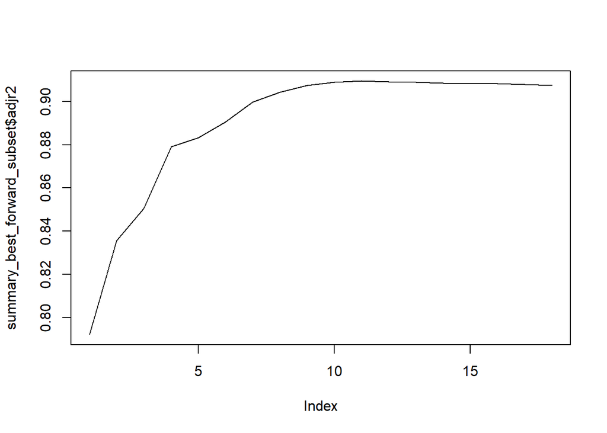

```r
plot(summary_best_forward_subset$adjr2, type="l")
```

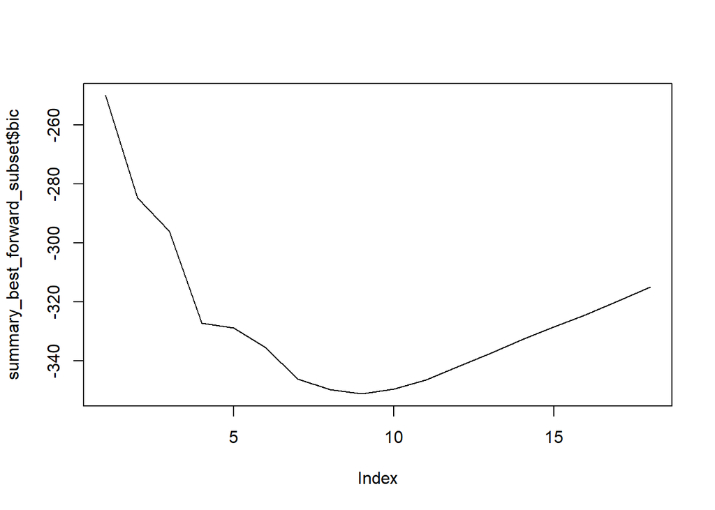

```r
plot(summary_best_forward_subset$bic, type="l")
```